# In-Class: September 19, 2018

## Part 1 (You can copy code from last time if you have it for this part)

### New York City Flights 13

```r
library(nycflights13)
library(dplyr)
```

```r
library(ggplot2)
flights
```

```
## # A tibble: 336,776 x 19
##     year month   day dep_time sched_dep_time dep_delay arr_time
##    <int> <int> <int>    <int>          <int>     <dbl>    <int>
##  1  2013     1     1      517            515      2.00      830
##  2  2013     1     1      533            529      4.00      850
##  3  2013     1     1      542            540      2.00      923
##  4  2013     1     1      544            545     -1.00     1004
##  5  2013     1     1      554            600     -6.00      812
##  6  2013     1     1      554            558     -4.00      740
##  7  2013     1     1      555            600     -5.00      913
##  8  2013     1     1      557            600     -3.00      709
##  9  2013     1     1      557            600     -3.00      838
## 10  2013     1     1      558            600     -2.00      753
## # ... with 336,766 more rows, and 12 more variables: sched_arr_time <int>,
## #   arr_delay <dbl>, carrier <chr>, flight <int>, tailnum <chr>,
## #   origin <chr>, dest <chr>, air_time <dbl>, distance <dbl>, hour <dbl>,
## #   minute <dbl>, time_hour <dttm>
```

### Basic Dplyr

The `dplyr` package uses verbs to perform data manipulation.

- `filter()` and `slice()`
- `arrange()`
- `select()` and `rename()`
- `distinct()`
- `mutate()` and `transmute()`
- `sample_n()` and `sample_frac()`

### Filtering Rows

1. Filter all flights on your birthday.

```r
#My birthday is April 4th, so I filter for that date in the flights tbl.
filter(flights, month == 4 & day == 4)
```

```
## # A tibble: 985 x 19
##     year month   day dep_time sched_dep_time dep_delay arr_time
##    <int> <int> <int>    <int>          <int>     <dbl>    <int>
##  1  2013     4     4       14           2245     89.0       124
##  2  2013     4     4      454            500    - 6.00      636
##  3  2013     4     4      511            515    - 4.00      808
##  4  2013     4     4      529            530    - 1.00      829
##  5  2013     4     4      538            540    - 2.00      847
##  6  2013     4     4      542            545    - 3.00      904
##  7  2013     4     4      544            545    - 1.00      913
##  8  2013     4     4      550            600    -10.0       900
##  9  2013     4     4      551            600    - 9.00      838
## 10  2013     4     4      552            600    - 8.00      703
## # ... with 975 more rows, and 12 more variables: sched_arr_time <int>,
## #   arr_delay <dbl>, carrier <chr>, flight <int>, tailnum <chr>,
## #   origin <chr>, dest <chr>, air_time <dbl>, distance <dbl>, hour <dbl>,
## #   minute <dbl>, time_hour <dttm>
```

2. Filter all flights in rows 567 - 589

```r
#We don't need to use the dplyr function filter to select a set of rows.
flights[567:589, ]
```

```
## # A tibble: 23 x 19
##     year month   day dep_time sched_dep_time dep_delay arr_time
##    <int> <int> <int>    <int>          <int>     <dbl>    <int>
##  1  2013     1     1     1653           1700    - 7.00     2005
##  2  2013     1     1     1654           1644     10.0      1752
##  3  2013     1     1     1654           1700    - 6.00     2020
##  4  2013     1     1     1655           1621     34.0      1804
##  5  2013     1     1     1655           1700    - 5.00     1953
##  6  2013     1     1     1655           1700    - 5.00     2027
##  7  2013     1     1     1655           1655      0        2025
##  8  2013     1     1     1656           1700    - 4.00     1941
##  9  2013     1     1     1657           1650      7.00     1921
## 10  2013     1     1     1657           1630     27.0      1948
## # ... with 13 more rows, and 12 more variables: sched_arr_time <int>,
## #   arr_delay <dbl>, carrier <chr>, flight <int>, tailnum <chr>,
## #   origin <chr>, dest <chr>, air_time <dbl>, distance <dbl>, hour <dbl>,
## #   minute <dbl>, time_hour <dttm>
```

### Arranging Rows

3. Use arrange() to order the data by year, month and day

```r
#This uses the dplyr function arrange to sort the data by year, month and day.
arrange(flights, year, month, day)
```

```
## # A tibble: 336,776 x 19
##     year month   day dep_time sched_dep_time dep_delay arr_time
##    <int> <int> <int>    <int>          <int>     <dbl>    <int>
##  1  2013     1     1      517            515      2.00      830
##  2  2013     1     1      533            529      4.00      850
##  3  2013     1     1      542            540      2.00      923
##  4  2013     1     1      544            545     -1.00     1004
##  5  2013     1     1      554            600     -6.00      812
##  6  2013     1     1      554            558     -4.00      740
##  7  2013     1     1      555            600     -5.00      913
##  8  2013     1     1      557            600     -3.00      709
##  9  2013     1     1      557            600     -3.00      838
## 10  2013     1     1      558            600     -2.00      753
## # ... with 336,766 more rows, and 12 more variables: sched_arr_time <int>,
## #   arr_delay <dbl>, carrier <chr>, flight <int>, tailnum <chr>,
## #   origin <chr>, dest <chr>, air_time <dbl>, distance <dbl>, hour <dbl>,
## #   minute <dbl>, time_hour <dttm>
```

4. Use desc() to arrange flights by arrival delay.

```r
#Adding desc() to the argument of arrange will sort the data in descending order (ascending is the default). The data is then sorted by arrival delay in descending order.
arrange(flights, desc(arr_delay))
```

```
## # A tibble: 336,776 x 19
##     year month   day dep_time sched_dep_time dep_delay arr_time
##    <int> <int> <int>    <int>          <int>     <dbl>    <int>
##  1  2013     1     9      641            900      1301     1242
##  2  2013     6    15     1432           1935      1137     1607
##  3  2013     1    10     1121           1635      1126     1239
##  4  2013     9    20     1139           1845      1014     1457
##  5  2013     7    22      845           1600      1005     1044
##  6  2013     4    10     1100           1900       960     1342
##  7  2013     3    17     2321            810       911      135
##  8  2013     7    22     2257            759       898      121
##  9  2013    12     5      756           1700       896     1058
## 10  2013     5     3     1133           2055       878     1250
## # ... with 336,766 more rows, and 12 more variables: sched_arr_time <int>,
## #   arr_delay <dbl>, carrier <chr>, flight <int>, tailnum <chr>,
## #   origin <chr>, dest <chr>, air_time <dbl>, distance <dbl>, hour <dbl>,
## #   minute <dbl>, time_hour <dttm>
```

### Select

5. Select columns containing date information.

```r
#This uses the dplyr function select to take out only the columns with date information (year, month, day).
select(flights, year, month, day)
```

```
## # A tibble: 336,776 x 3
##     year month   day
##    <int> <int> <int>
##  1  2013     1     1
##  2  2013     1     1
##  3  2013     1     1
##  4  2013     1     1
##  5  2013     1     1
##  6  2013     1     1
##  7  2013     1     1
##  8  2013     1     1
##  9  2013     1     1
## 10  2013     1     1
## # ... with 336,766 more rows
```

6. Select columns including only plane information.

```r
#Again, this uses the select function to take out the columns with plane information (carrier, tailnum)
select(flights, carrier, tailnum)
```

```
## # A tibble: 336,776 x 2
##    carrier tailnum
##    <chr>   <chr>
##  1 UA      N14228
##  2 UA      N24211
##  3 AA      N619AA
##  4 B6      N804JB
##  5 DL      N668DN
##  6 UA      N39463
##  7 B6      N516JB
##  8 EV      N829AS
##  9 B6      N593JB
## 10 AA      N3ALAA
## # ... with 336,766 more rows
```

7. Rename tailnum to tail_num

```r
#The rename function can change the column named "tailnum" to "tail_num", note the new name goes first in the second argument of the function.
flights <- rename(flights, tail_num = tailnum)
```

### Mutating Rows

8. Create a variable called gain which describes the difference between arrival delap and departure delay.

```r
#The mutate function can add new columns to a table that use data from existing columns. This can be used to add a new column "gain" which is the difference of arrival delay and departure delay.
mutate(flights, gain = arr_delay - dep_delay)
```

```
## # A tibble: 336,776 x 20
##     year month   day dep_time sched_dep_time dep_delay arr_time
##    <int> <int> <int>    <int>          <int>     <dbl>    <int>
##  1  2013     1     1      517            515      2.00      830
##  2  2013     1     1      533            529      4.00      850
##  3  2013     1     1      542            540      2.00      923
##  4  2013     1     1      544            545     -1.00     1004
##  5  2013     1     1      554            600     -6.00      812
##  6  2013     1     1      554            558     -4.00      740
##  7  2013     1     1      555            600     -5.00      913
##  8  2013     1     1      557            600     -3.00      709
##  9  2013     1     1      557            600     -3.00      838
## 10  2013     1     1      558            600     -2.00      753
## # ... with 336,766 more rows, and 13 more variables: sched_arr_time <int>,
## #   arr_delay <dbl>, carrier <chr>, flight <int>, tail_num <chr>,
## #   origin <chr>, dest <chr>, air_time <dbl>, distance <dbl>, hour <dbl>,
## #   minute <dbl>, time_hour <dttm>, gain <dbl>
```

9. Create a variable called speed which is distance over time in hours.

```r
#The mutate function is used again to add a speed variable to the tbl.
mutate(flights, speed = distance/(air_time/60))
```

```
## # A tibble: 336,776 x 20
##     year month   day dep_time sched_dep_time dep_delay arr_time
##    <int> <int> <int>    <int>          <int>     <dbl>    <int>
##  1  2013     1     1      517            515      2.00      830
##  2  2013     1     1      533            529      4.00      850
##  3  2013     1     1      542            540      2.00      923
##  4  2013     1     1      544            545     -1.00     1004
##  5  2013     1     1      554            600     -6.00      812
##  6  2013     1     1      554            558     -4.00      740
##  7  2013     1     1      555            600     -5.00      913
##  8  2013     1     1      557            600     -3.00      709
##  9  2013     1     1      557            600     -3.00      838
## 10  2013     1     1      558            600     -2.00      753
## # ... with 336,766 more rows, and 13 more variables: sched_arr_time <int>,
## #   arr_delay <dbl>, carrier <chr>, flight <int>, tail_num <chr>,
## #   origin <chr>, dest <chr>, air_time <dbl>, distance <dbl>, hour <dbl>,
## #   minute <dbl>, time_hour <dttm>, speed <dbl>
```

### Summarise

10. Summarise the average delay for all flights.

```r
#This summary gives the average arrival delay for all flights, with NA's removed.
summarise(flights, average_delay = mean(arr_delay[!is.na(arr_delay)]))
```

```
## # A tibble: 1 x 1
##   average_delay
##           <dbl>
## 1          6.90
```

## Overall Questions

11. Split the complete dataset into individual planes and then summarise each plane by counting the number of flights (count = n()) and computing the average distance and arrival delay . Then plot this:

```
ggplot(delay, aes(dist, delay)) +
  geom_point(aes(size = count), alpha = 1/2) +
  geom_smooth() +
  scale_size_area()
```

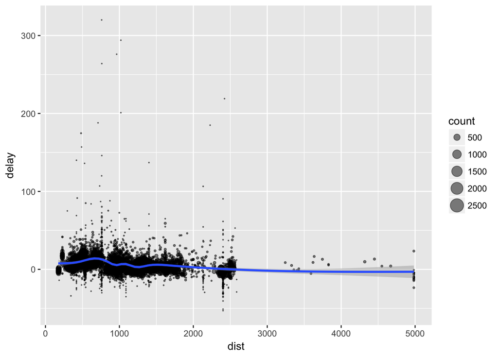

```r
#The group_by function can be used to split the dataset into individual planes (which are distinguished by their tail number). After the planes are grouped, the summarise function can count the number of flights for each plane and their average distance and arrival delay (again the NA's are removed).
delay <- flights %>%
  group_by(tail_num) %>%
    summarise(count = n(), dist = mean(distance[!is.na(distance)]), delay = mean(arr_delay[!is.na(arr_delay)]))

ggplot(delay, aes(dist, delay)) +
  geom_point(aes(size = count), alpha = 1/2) +
  geom_smooth() +
  scale_size_area()
```

```r
#Each individual plane is represented as a dot on the graph, with its average distance travelled plotted against its average delay in arrival. The size of the dot gives an idea of how many flights the plane has made, with a key to the sizes given on the graph.
```

12. Find the number of planes and the number of flights that go to each possible destination.

```r
#First, you have to group by the destination of the flights. Then, to summarise - first the number of planes is equal to the number of distinct tail numbers that go to a particular destination, this can be obtained with the n_distinct function. Finally, the number of flights is just equal to the number of observations for each destination, which can be obtained with the n() function.
flights %>%
  group_by(dest) %>%
    summarise(num_planes = n_distinct(tail_num), num_flights = n())
```

```
## # A tibble: 105 x 3
##    dest  num_planes num_flights
##    <chr>      <int>       <int>
##  1 ABQ          108         254
##  2 ACK           58         265
##  3 ALB          172         439
##  4 ANC            6           8
##  5 ATL         1180       17215
##  6 AUS          993        2439
##  7 AVL          159         275
##  8 BDL          186         443
##  9 BGR           46         375
## 10 BHM           45         297
## # ... with 95 more rows
```